# Student Mental Health Analysis Using Classification Modeling

## Boxplot: study hours by risk level

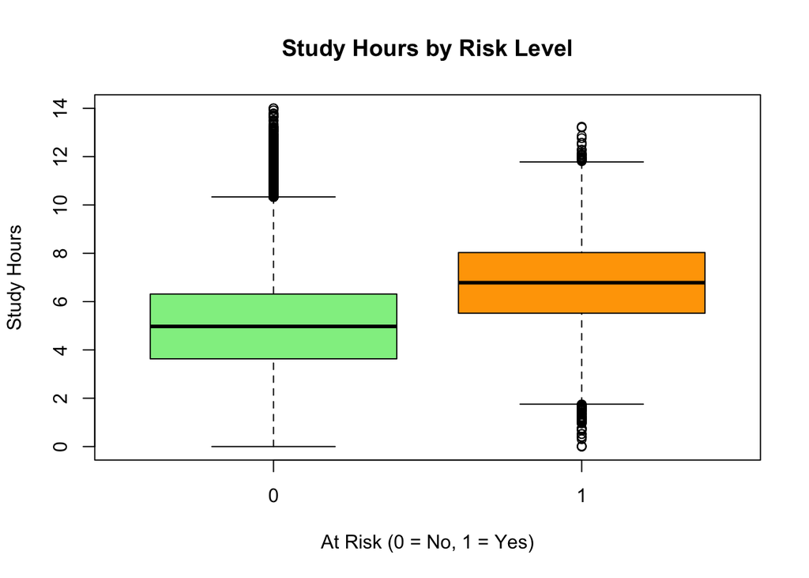

```r
boxplot(study_hours_per_day ~ AtRisk,
        data = df,
        main = "Study Hours by Risk Level",
        xlab = "At Risk (0 = No, 1 = Yes)",
        ylab = "Study Hours",
        col = c("lightgreen", "orange"))
```

## Boxplot: stress level by risk

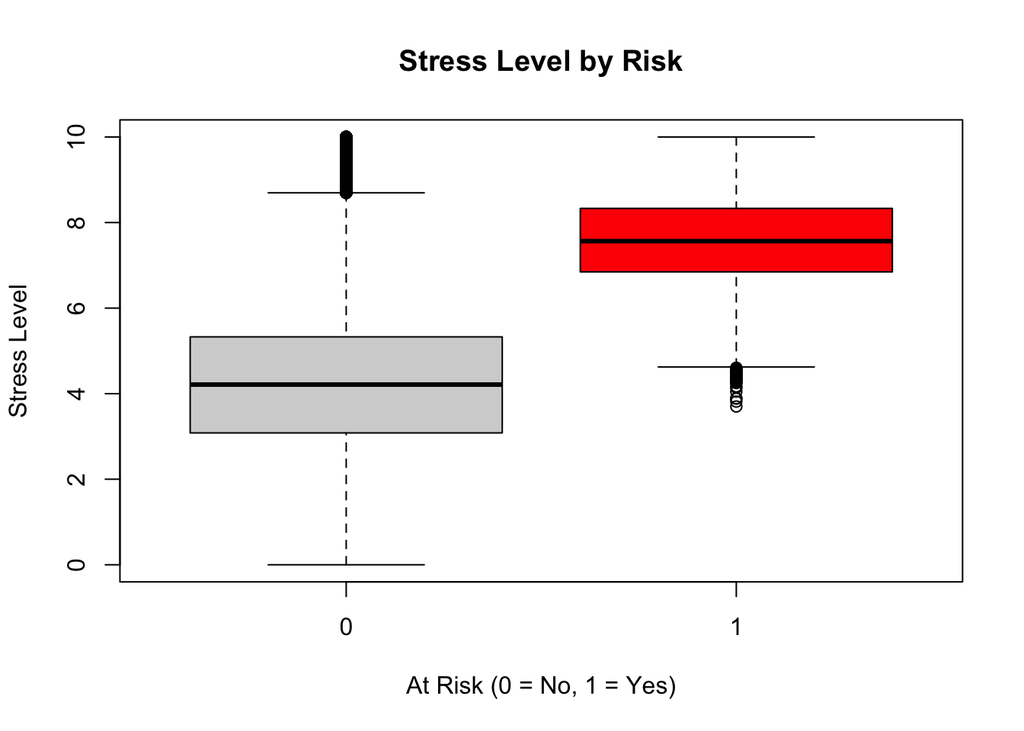

```r
boxplot(stress_level ~ AtRisk,
        data = df,
        main = "Stress Level by Risk",
        xlab = "At Risk (0 = No, 1 = Yes)",
        ylab = "Stress Level",
        col = c("lightgray", "red"))
```

## Boxplot: anxiety by risk

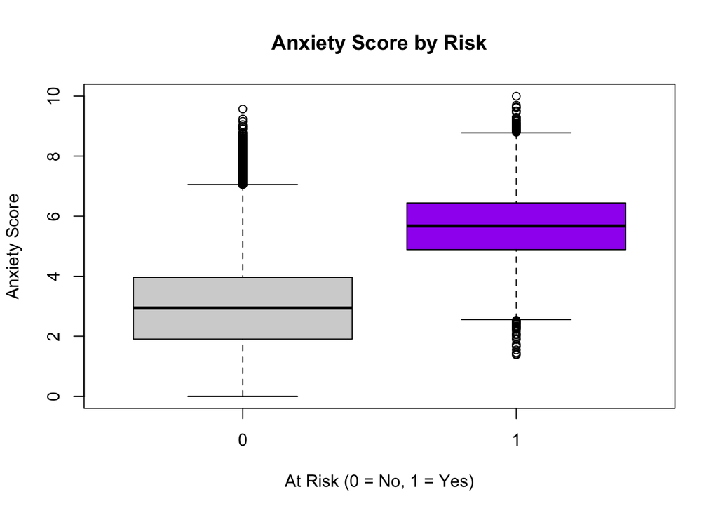

```r
boxplot(anxiety_score ~ AtRisk,
        data = df,
        main = "Anxiety Score by Risk",
        xlab = "At Risk (0 = No, 1 = Yes)",
        ylab = "Anxiety Score",
        col = c("lightgray", "purple"))
```

## Boxplot: depression by risk

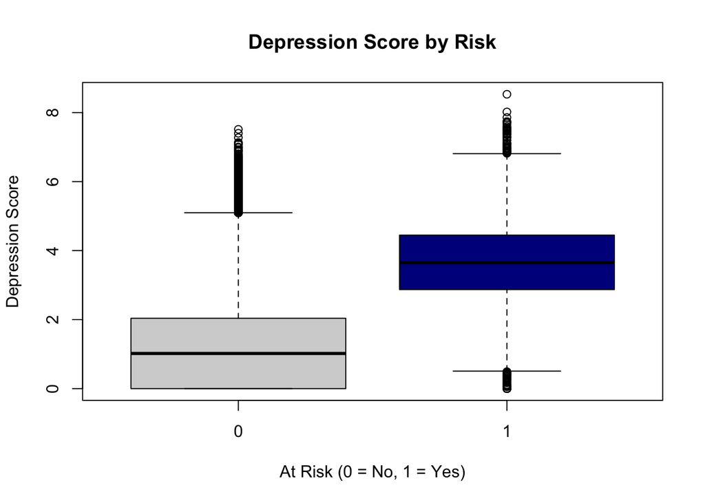

```r
boxplot(depression_score ~ AtRisk,
        data = df,
        main = "Depression Score by Risk",
        xlab = "At Risk (0 = No, 1 = Yes)",
        ylab = "Depression Score",
        col = c("lightgray", "darkblue"))
```

Comparisons between at-risk and non-risk students show consistent directional differences across all variables . At-risk students tend to sleep less and study more, although these differences show substantial overlap, suggesting limited standalone predictive power. In contrast, stress, anxiety, and depression exhibit clear separation between groups, indicating strong discriminative ability. However, this separation also raises concerns about potential overlap with the outcome variable itself, as these measures closely reflect mental health status rather than acting as independent predictors.

## Relationships Between Variables

## Heat Map of Variables

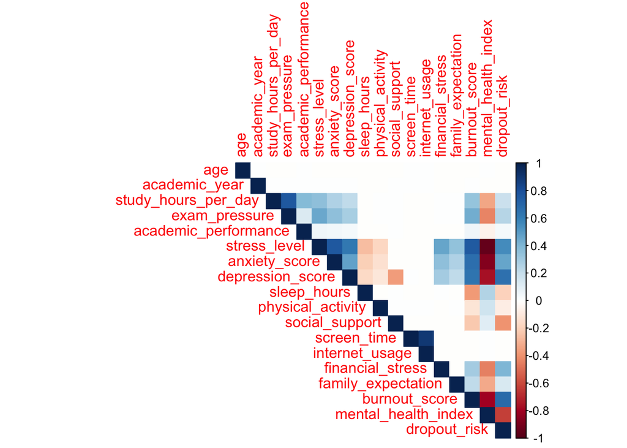

```r
library(corrplot)

corrplot(cor(df[, sapply(df, is.numeric)], use = "complete.obs"),
         method = "color",
         type = "upper")
```

The correlation analysis reveals strong relationships among stress, anxiety and depression. This indicates the presence of multicollinearity . This suggests that these variables may represent a shared underlying construct of psychological distress rather than independent factors. As a result, including all three variables may introduce redundancy into the model without substantially improving predictive performance. These findings provide the foundation for the classification models by highlighting which variables are most likely to contribute to predictive performance

# Classification Modeling

## Create full dataset for modeling

```r
df_full <- df[, c("AtRisk",
                  "sleep_hours",
                  "study_hours_per_day",
                  "screen_time",
                  "physical_activity",
                  "financial_stress",
                  "exam_pressure",
                  "academic_performance",
                  "stress_level",
                  "anxiety_score",
                  "depression_score",
                  "family_expectation")]
```